# DAWeek3

Robert Edwards

25 January 2019

## 1. Inroduction

Now that we are comfortable with visualizing and manipulating data in R, we can now proceed onto modelling data. The key idea behind modelling data is to infer the relationship between an:

- **outcome (or response) variable y** and
- an **explanatory (or predictor) variable x**, which can also be referred to as an **independent variable or covariate.**

Modelling can be used for two purposes:

1. **Explanation**: For describing the relationship between an outcome variable y and an explanatory variable x, and determining the potential significance of such relationships using quantifiable measures.
2. **Prediction**: for predicting the outcome variable **y** given information from one or more explanatory variables.

There are many different modelling techniques. However, we will begin with one of the easier to understand and commonly-used approaches, **linear regression**. In particular, we will start by looking at **simple linear regression**, where we only have one explanatory variable.

**Note**: Additional information and examples can be found in [Chapter 6 of An Introduction to Statistical and Data Science via R](https://moderndive.com/index.html).

## 2. Simle Linear Regression

For a response variable **y** and an explanatory variable **x**, the data can be expressed as:

$$(y_i,x_i), i=1,.,n.$$

That is, we have **n** observations of **y** and **x**. A statistical model is a mathematical statement describing the variability in a random variable y, which includes any relationship with the explanatory variable **x**. The inclusion of random (unpredictable) components ***, makes the model statistical, rather than deterministic. A simple linear regression model involves, as the name suggests, fitting a linear regression line to the data. Hence, a simple linear regression model can be written as follows:

$$y_i=\alpha+\beta x_i+\epsilon_i,\ \ \ \epsilon_i ??? N(0,\epsilon^2)$$
,

- $y_i$ is the $i^th$ observation of the response variable;
- $\alpha$ is the **intercept** of the regression line;
- $\beta$ is the **slope** of the regression line;
- $x_i$ is the $ith$ observation of the explanatory variable; and
- $\epsilon_i$ is the $ith$ random component.

The random components, $\epsilon_i$, are normally distributed with mean zero and constant variance $??^2$, such that we are essentially adding random white noise to the deterministic part of the model $(\alpha+\beta x_i)$. Thus, the full probability model for $y_i$ given $x_i$ $(y_i|x_i)$ can be written as

$$y_i|x_i ??? N(\alpha+\beta x_i,\sigma^2)$$

Hence, the mean comes from the deterministic part of the model, while the variance comes from the random part. We shall now look into fitting a simple linear regression model to some data.

## 3. Simple Linear Regression with one Numerical Exlanatory Variable

Student feedback in higher education is extremely important when it comes to the evaluation of teaching techniques, materials, and improvements in teaching methods and technologies. However, there have been studies into potential bias factors when feedback is provided, such as the physical appearance of the teacher; see Economics of Education Review for details. Here, we shall look at a study from student evaluations of **n=463** professors from The University of Texas at Austin. In particular, we will examine the evaluation scores of the instructors based purely on one numerical variable: their beauty score. Therefore, our simple linear regression model will consist of:

the numerical outcome variable teaching score (**y**); and the numerical explanatory variable beauty score (**x**).

### Explanatory Data Analysis

Before you ever do any statistical modelling of data, you should always perform an **exploratory data analysis** of the data. Performing an exploratory data analysis can give us an idea of the distribution of the data, and whether it contains any strange values, such as **outliers** or **missing values**. However, more importantly, it is used to inform which statistical model we should fit to the data. An exploratory data analysis may involve:

1. Looking at the raw values of the data, either by looking at the spreadsheet directly, or using R.
2. By computing various summary statistics, such as the five-number summary, means, and standard deviations.
3. Plotting the data using various data visualization techniques.

Let’s examine the data evals. We can look at the raw values from evals using the RStudio pop-up spreadsheet viewer using:

```r
#View(evals)
```

```r
head(evals)
```

```
## # A tibble: 6 x 13
##      ID score   age bty_avg gender ethnicity language rank  pic_outfit
##   <int> <dbl> <int>   <dbl> <fct>  <fct>     <fct>    <fct> <fct>
## 1     1   4.7    36       5 female minority  english  tenu… not formal
## 2     2   4.1    36       5 female minority  english  tenu… not formal
## 3     3   3.9    36       5 female minority  english  tenu… not formal
## 4     4   4.8    36       5 female minority  english  tenu… not formal
## 5     5   4.6    59       3 male   not mino… english  tenu… not formal
## 6     6   4.3    59       3 male   not mino… english  tenu… not formal
## # … with 4 more variables: pic_color <fct>, cls_did_eval <int>,
## #   cls_students <int>, cls_level <fct>
```

```r
nrow(evals)
```

```
## [1] 463
```

At the moment we are only really interested in the instructors teaching (score) and beauty (bty_avg) scores, and so we can look at a subset of the data as follows:

```r
evals.scores <- evals %>%
  select(score, bty_avg)
```

**Task**: Create a new object evals.10cases by replace the select function with the sample_n function to look at a random subset of 10 instructors.

```r
evals.10cases <- evals %>%
  sample_n(10)
```

The outcome variable *score* is a numerical average of the average teaching score based on students’ evaluations between 1 and 5. The explanatory variable *bty_avg* is the numerical variable of the average beauty score from a panel of six students’ scores between 1 and 10. As both variables are numerical, we can produce graphical summaries using boxplots and numerical summaries by calculating summary statistics using the *skim* function from the *skimr* package as follows:

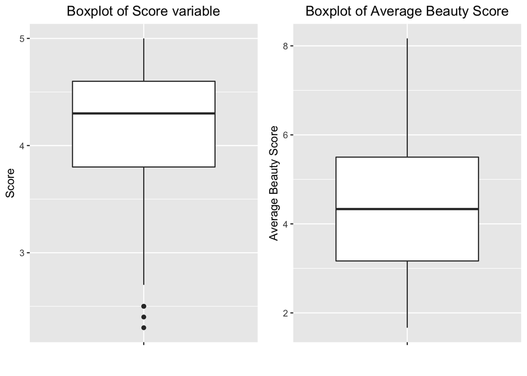

```r
score.boxplot <- ggplot(evals.scores, aes(x = "", y = score)) +
  geom_boxplot() +
  labs(x = "", y = "Score",
       title = "Boxplot of Score variable")+
        theme(plot.title = element_text(hjust = 0.5))
        #This function centres the plot title

bty_avg.boxplot <- ggplot(evals.scores, aes(x = "", y = bty_avg)) +
  geom_boxplot() +
  labs(x = "", y = "Average Beauty Score",
       title = "Boxplot of Average Beauty Score")+
        theme(plot.title = element_text(hjust = 0.5))
        #This function centres the plot title

grid.arrange(score.boxplot, bty_avg.boxplot, ncol=2)
```

```r
# This function shows the 2 plots side by side
```

```r
evals.scores %>%
  skim()
```

```
## Skim summary statistics
##  n obs: 463
##  n variables: 2
##
## ── Variable type:numeric ─────────────────────────────────────────────────────────────────────────────
##  variable missing complete   n mean   sd   p0  p25  p50 p75 p100     hist
##   bty_avg       0      463 463 4.42 1.53 1.67 3.17 4.33 5.5 8.17 ▂▅▅▇▃▃▂▁
##     score       0      463 463 4.17 0.54 2.3  3.8  4.3  4.6 5    ▁▁▂▃▅▇▇▆
```

- `missing`: the number of missing values.
- `complete`: the number of non-missing values.
- `n`: the total number of observations.
- `mean`: the mean or average.
- `sd`: the standard deviation.
- `p0`: the $0th$ percentile: the value at which 0% of values are smaller than it (i.e. the minimum).
- `p25`: the $25th$ percentile: the value at which 25% of values are smaller than it (i.e. the 1st quartile).
- `p50`: the $50th$ percentile: the value at which 50% of values are smaller than it (i.e. the median).
- `p75`: the $75th$ percentile: the value at which 75% of values are smaller than it (i.e. the 3rd quartile).
- `p100`: the $100th$ percentile: the value at which 100% of values are smaller than it (i.e. the maximum).
- hist: provides a snapshot of a histogram of the variable.

These summary statistics give us an idea of how both variables are distributed. For example, the mean teaching score (`score`) is 4.17 out 5, while the mean beauty score (`bty_avg`) is 4.42 out of 10. Also, the middle 50% of the data for `score` lies between 3.8 and 4.6, while the middle 50% of `bty_avg` lies between 3.17 and 5.5.

### Correlation

The above summary statistics provide information about each variable separately. However, we are interested in a potential relationship between the two variables and as such it would be of interest to evaluate some statistic that considers both variables simultaneously. One such statistic is the **correlation**, which ranges between -1 and 1 and describes the strength of the linear relationship between two numerical variables, such that

-1 indicates a perfect *negative relationship*. That is, as the values of one variable increase, the values of the other decrease. 0 indicates no relationship. The values of both variables increase/decrease independently of one another. 1 indicates a perfect *positive relationship*. That is, the values of both variables increase simultaneously.

The correlation coefficient can be computed in R using the `get_correlation` function from the `moderndive` package. The function requires two numerical variables separated by `~` (or ‘tilde’), much like the formula syntax, such that the outcome variable `score is put on the left-hand-side of the formula, and the explanatory variable bty_avg is placed on the right-hand-side of the formula:`

```r
evals.scores %>%
  get_correlation(formula = score ~ bty_avg)
```

```
## # A tibble: 1 x 1
##   correlation
##         <dbl>
## 1       0.187
```

Here, we are given a correlation coefficient of 0.187 for the relationship between teaching (`score`) and beauty (`bty_avg`) scores. This suggests a rather *weakly positive* linear relationship between the two variables. There is some subjective interpretation surrounding correlation coefficients not very close to -1, 0, 1.

**Note**: the `cor` function can also be used to compute the correlation coefficient. For more details type `?cor` into the R console.

### Visualizing the Data

The next step in our exploratory data analysis is to visualize the data using appropriate plotting techniques. Here, a scatterplot is appropriate since both `score` and `bty_avg` are numerical variables:

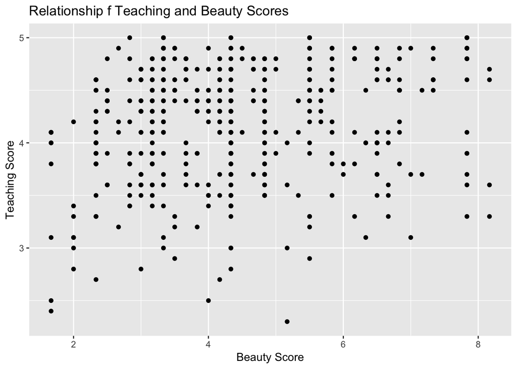

```r
ggplot(evals.scores, aes(x = bty_avg, y= score)) +
  geom_point() +
  labs(x = "Beauty Score",
       y = "Teaching Score",
       title = "Relationship f Teaching and Beauty Scores")
```

What can we observe from the scatterplot? Well, here it can be hard to see the weakly positive linear relationship suggested by the correlation coefficient (0.187), which is why our correlation coefficient is considered very weak in the verbal interpretation.

Additionally, as our numerical variables are averages of integers (or whole numbers), a lot of the values will be plotted on top of one another. Remember, from Week 1, that this is referred to as **over-plotting**, and can be alleviated by slightly nudging (**jittering**) the points in a random direction. For example, let’s look at the three points in the top-right of the scatterplot that have a beauty score slightly less than 8. Are there really only three values plotted there, or are there more that we cannot see due to over-plotting? Let’s find out by adding some jitter to the plot:

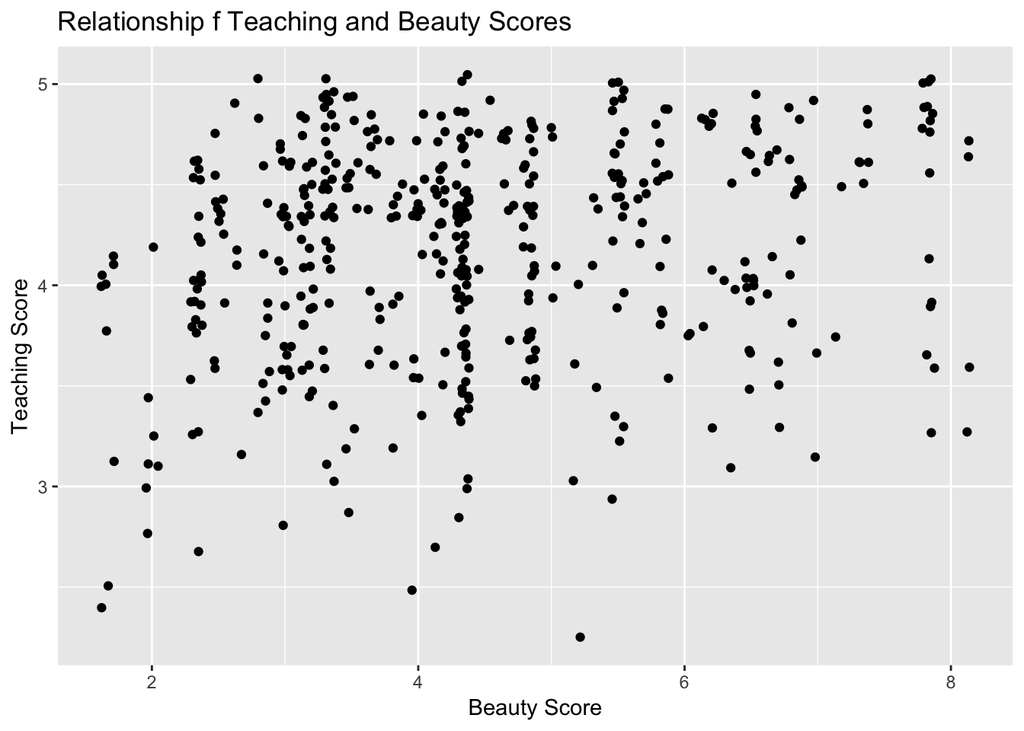

```r
ggplot(evals.scores, aes(x = bty_avg, y= score)) +
  geom_jitter(width = 0.05, height = 0.05) +
  labs(x = "Beauty Score",
       y = "Teaching Score",
       title = "Relationship f Teaching and Beauty Scores")
```

1. There are actually more than just three points plotted in the top-right; and
2. There are more instructors with a beauty score between 3 and 4.5 than originally appears due to over-plotting.

### Formal Analysis

After completing an exploratory data analysis the next step is to perform a **formal analysis** on the data. This involves constructing an appropriate statistical model from the information gathered during the exploratory data analysis step. Here, we shall be fitting a simple linear regression model to the data on teaching and beauty scores, where our objective is to acquire the best fitting regression line. This is done by finding estimates of the intercept () and slope () which give us the best-fitting line to the data. This can be done in R using the `lm` function to fit a linear model to the data as follows:

```r
model <- lm(score ~ bty_avg, data = evals.scores)
```

+$\alpha^=3.88034$ is the intercept coefficient and means that, for any instructor with a `bty_avg = 0`, their average teaching `score` would be 3.8803. Note that `bty_avg = 0` is not actually possible as `bty_avg` is an average of beauty scores ranging between 1 and 10. +$\beta^=0.06664$ is the slope coefficient associated with the exploratory variable `bty_avg`, and summarizes the relationship between `score` and `bty_avg`. That is, as `bty_avg` increases, so does `score`, such that ++For every 1 unit increase in `bty_avg`, there is an associated increase of, on average, 0.06664 units of `score`.

Finally, we can superimpose our best-fitting line onto our scatterplot to see how it fits through the points using the `geom_smooth` function as follows:

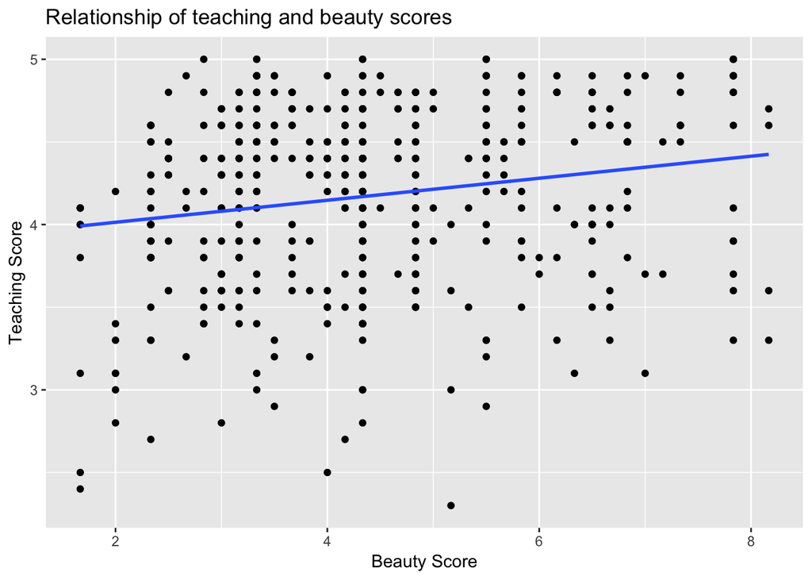

```r
ggplot(evals.scores, aes(x = bty_avg, y = score)) +
  geom_point() +
  labs(x = "Beauty Score", y = "Teaching Score",
     title = "Relationship of teaching and beauty scores") +
  geom_smooth(method = "lm", se = FALSE)
```

Now that we have fitted our simple linear regression model to the data, how do we use it to obtain information on individual data points? This can be done by looking at the **fitted values**. For example, let’s say we are interested in looking at the 21st instructor who has the following teaching and beauty scores:

```r
evals.scores %>%
  slice(21)
```

```
## # A tibble: 1 x 2
##   score bty_avg
##   <dbl>   <dbl>
## 1   4.9    7.33
```

What would the `score` be on our best-fitting line for this instructor with a `bty_avg` of 7.33? We simply plug the instructor’s `bty_avg` into our regression model:

$$score^=3.88034+0.06664???bty\_avg=3.88034+0.06664???7.33=4.369$$

The regression model gives our instructor a `score` of 4.369. However, we know the `score` of the instructor is 4.9 meaning that our model was out by 0.531. This is known as the **residual ()** and can be thought of as the error or lack of fit of the regression line. In this case, the residual is given by:

$$\epsilon^=y???y^=4.9???4.369=0.531$$

**Task**: Obtain the observed `score` and `bty_avg` for the 13th instructor.

```r
evals.scores %>%
  slice(13)
```

```
## # A tibble: 1 x 2
##   score bty_avg
##   <dbl>   <dbl>
## 1   4.6    3.17
```

**Quiz**: Using the regression model, find the fitted value of `score` for the 13th instructor?

```r
evals.scores %>%
  slice(13) %>%
  summarize(3.88034+0.06664*bty_avg)
```

```
## # A tibble: 1 x 1
##   `3.88034 + 0.06664 * bty_avg`
##                           <dbl>
## 1                          4.09
```

**Quiz**: Using the regression model, find the value of the `residual error` for the 56th instructor?

```r
evals.scores %>%
  slice(56) %>%
  summarize(score - (3.88034+0.06664*bty_avg))
```

```
## # A tibble: 1 x 1
##   `score - (3.88034 + 0.06664 * bty_avg)`
##                                     <dbl>
## 1                                   0.353
```

To obtain the fitted values and residuals for all instructors within the data set we can use the `get_regression_points` function:

```r
regression.points <- get_regression_points(model)
regression.points
```

```
## # A tibble: 463 x 5
##       ID score bty_avg score_hat residual
##    <int> <dbl>   <dbl>     <dbl>    <dbl>
##  1     1   4.7    5         4.21    0.486
##  2     2   4.1    5         4.21   -0.114
##  3     3   3.9    5         4.21   -0.314
##  4     4   4.8    5         4.21    0.586
##  5     5   4.6    3         4.08    0.52
##  6     6   4.3    3         4.08    0.22
##  7     7   2.8    3         4.08   -1.28
##  8     8   4.1    3.33      4.10   -0.002
##  9     9   3.4    3.33      4.10   -0.702
## 10    10   4.5    3.17      4.09    0.409
## # … with 453 more rows
```

The table provides us with information on the:

- `score`: the observed value of the outcome variable **y**;
- `bty_avg`: the values of the explanatory variable **x**;
- `score_hat`: the values of the fitted values **y^**; and
- `residual`: the residuals **y???y^**.

**Quiz**: Using the table above, find the fitted value of `score` for the 72nd instructor?

```r
regression.points %>%
  slice(72)
```

```
## # A tibble: 1 x 5
##      ID score bty_avg score_hat residual
##   <int> <dbl>   <dbl>     <dbl>    <dbl>
## 1    72   3.9    4.83      4.20   -0.302
```

**Quiz**: Using the table above, find the value of the `residual` error for the 44th instructor?

```r
regression.points %>%
  slice(44)
```

```
## # A tibble: 1 x 5
##      ID score bty_avg score_hat residual
##   <int> <dbl>   <dbl>     <dbl>    <dbl>
## 1    44   4.8    4.67      4.19    0.609
```

### Assessing Model Fit

When we fit a simple linear regression model there are five main assumptions that we need to hold true in order for the model to be an appropriate fit to the data. These assumptions are:

1. The deterministic part of the model captures all the non-random structure in the data, i.e. the residuals have mean zero.
2. The scale of the variability of the residuals is constant at all values of the explanatory variables.
3. The residuals are normally distributed.
4. The residuals are independent.
5. The values of the explanatory variables are recorded without error. One way we can check our first assumption is to plot the residuals (`residuals`) against the explanatory variable (`bty_avg`). From this we should be able to check that the explanatory variable has a linear relationship with the outcome variable (`score`). We can plot the residuals against our explanatory variable using:

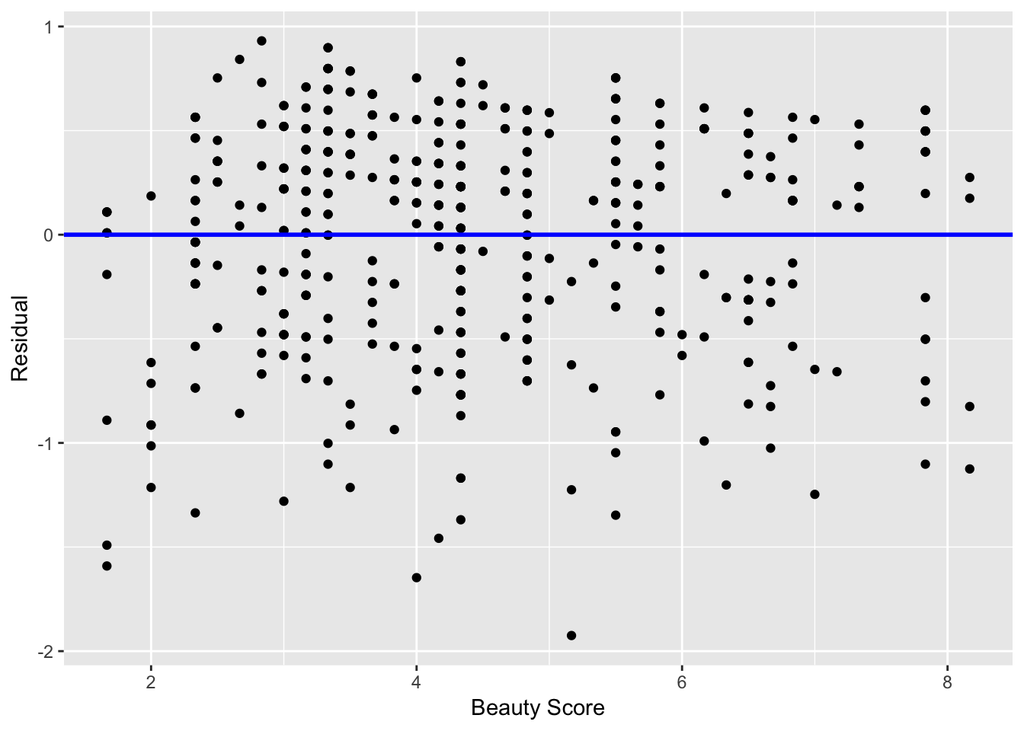

```r
ggplot(regression.points, aes(x = bty_avg, y = residual)) +
  geom_point() +
  labs(x = "Beauty Score", y = "Residual") +
  geom_hline(yintercept = 0, col = "blue", size = 1)
```

Ideally, for the first assumption to hold we should observe the following:

- There should be no systematic pattern, i.e. the residuals should appear randomly scattered.
- The residuals should have mean zero. That is, they should be evenly scattered above and below the zero line. This is because the regression model will overestimate some of the fitted values, but it will also underestimate some, and hence, on average, they should even out to have mean zero. We can examine our first two assumptions by also plotting the residuals against the fitted values as follows:

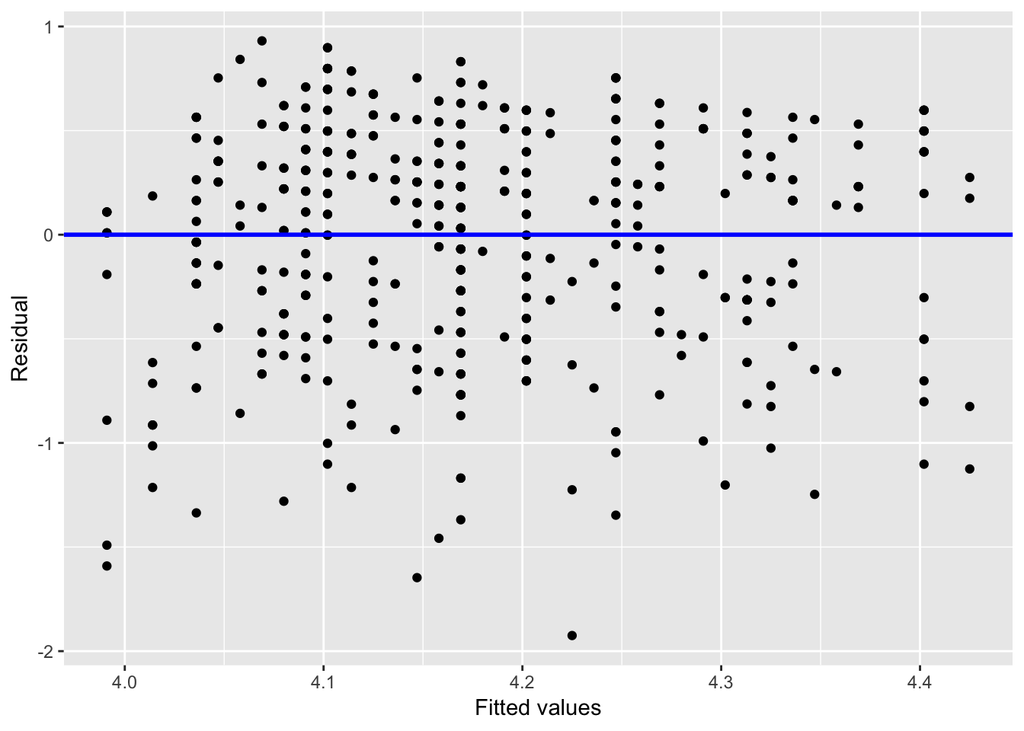

```r
ggplot(regression.points, aes(x = score_hat, y = residual)) +
  geom_point() +
  labs(x = "Fitted values", y = "Residual") +
  geom_hline(yintercept = 0, col = "blue", size = 1)
```

From the plot of the residuals against the fitted values we want to examine whether:

- The residuals have mean zero.
- If the residuals have constant variance across all levels of the fitted values. That is, the range (or spread) of the residuals should be similar across all levels of the fitted values and display no obvious changes in variability.

To assess our third assumption that the residuals are normally distributed we can simply plot a histogram of the residuals:

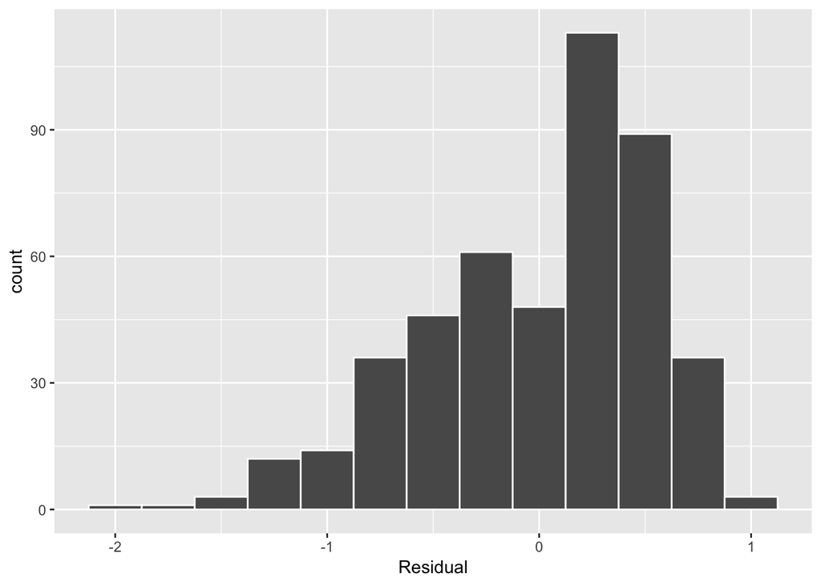

```r
ggplot(regression.points, aes(x = residual)) +
  geom_histogram(binwidth = 0.25, color = "white") +
  labs(x = "Residual")
```

Ideally, for the assumption of normally distributed residuals, the histogram should be bell-shaped and centred at zero, i.e. the residuals have mean zero. However, in practice this will almost never be the case, and as such, like the plots of the residuals, there is some subjectivity in whether you believe the assumptions hold. For instance, here we can see that the histogram is slightly skewed to the left in that the distribution has a longer tail to the left. However, in my opinion, this is not of much concern as the histogram appears to be relatively symmetrical and bell-shaped, and as such the assumption of normally distributed random errors appears valid in this case.

Finally, assumptions 4. and 5. are often justified on the basis of the experimental context and are not formally examined.

## 3. Simple Linear Regression with one Categorical Explanatory Variable

Here, we will fit a simple linear regression model were the explanatory variable is categorical. A **categorical variable** is a variable of a fixed number of possible values, assigning units to particular groups (or categories) based on qualitative properties. In R, a **categorical variable** is called a `factor`.

We shall examine the `gapminder` data set from the `gapminder` library. This is a data set on life expectancy across various countries around the world. We will explore life expectancy and its potential differences:

- Between continents: Does life expectancy vary, on average, between the five continents of the world?; and
- Within continents: Does life expectancy vary, on average, within the five continents of the world? Thus, we will be looking at:
- life expectancy as our numerical outcome variable **y**; and
- the continent a country is within as our categorical variable **x**.

### Exploratior Data Analysis

Let’s examine a subset of the `gapminder` data set relating to the year 2007. That is, we use the `filter` function to choose only the observations pertaining to 2007, and then `select` the variables we are interested in:

```r
gapminder2007 <- gapminder %>%
  filter(year == 2007) %>%
  select(country, continent, lifeExp)
```

The new data set can be examined using either the `View` or `glimpse` functions, i.e.

```r
glimpse(gapminder2007)
```

```
## Observations: 142
## Variables: 3
## $ country   <fct> Afghanistan, Albania, Algeria, Angola, Argentina, Aust…
## $ continent <fct> Asia, Europe, Africa, Africa, Americas, Oceania, Europ…
## $ lifeExp   <dbl> 43.828, 76.423, 72.301, 42.731, 75.320, 81.235, 79.829…
```

Here, we can see that both `country` and `continent` are factors (`fct`), which is how R stores categorical variables. Similarly to our previous exploratory data analysis, we can obtain summary statistics using the `skim` function. First, let’s take a look at the life expectancy (`lifeExp`) and `continent` variables:

```r
gapminder2007 %>%
  select(continent, lifeExp) %>%
  skim()
```

```
## Skim summary statistics
##  n obs: 142
##  n variables: 2
##
## ── Variable type:factor ──────────────────────────────────────────────────────────────────────────────
##   variable missing complete   n n_unique
##  continent       0      142 142        5
##                          top_counts ordered
##  Afr: 52, Asi: 33, Eur: 30, Ame: 25   FALSE
##
## ── Variable type:numeric ─────────────────────────────────────────────────────────────────────────────
##  variable missing complete   n  mean    sd    p0   p25   p50   p75 p100
##   lifeExp       0      142 142 67.01 12.07 39.61 57.16 71.94 76.41 82.6
##      hist
##  ▂▂▂▂▂▃▇▇
```

The summary output for the numerical outcome variable `lifeExp` is the same as we have seen previously. However, for the categorical variable `continent` we obtain:

- `n_unique`: the number of levels/categories of the variable, i.e. the number of continents.
- `top_counts`: the number of counts of each level/categories.
- `ordered`: whether the variable is ordinal or not. That is, whether or not the ordering of the categories matter. “0” means that it is **not** ordered, “1” means that it is ordered.

We can summarize any differences in life expectancy by continent by taking a look at the median and mean life expectancies of each continent using the `group_by` and `summarize` functions as follows:

```r
lifeExp.continent <- gapminder2007 %>%
  group_by(continent) %>%
  summarize(median = median(lifeExp), mean = mean(lifeExp))
lifeExp.continent
```

```
## # A tibble: 5 x 3
##   continent median  mean
##   <fct>      <dbl> <dbl>
## 1 Africa      52.9  54.8
## 2 Americas    72.9  73.6
## 3 Asia        72.4  70.7
## 4 Europe      78.6  77.6
## 5 Oceania     80.7  80.7
```

Boxplots are often used when examining the distribution of a numerical outcome variable across different levels of a categorical variable:

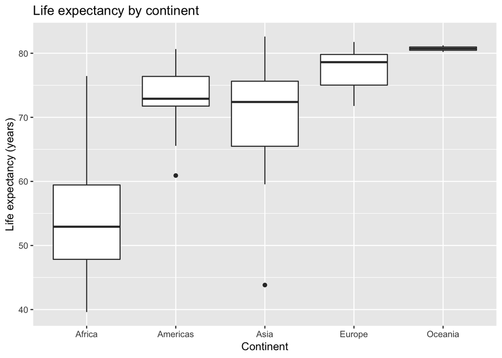

```r
ggplot(gapminder2007, aes(x = continent, y= lifeExp)) +
  geom_boxplot() +
  labs(x = "Continent", y = "Life expectancy (years)",
       title = "Life expectancy by continent")
```

Here, we can see that the middle 50% of the life expectancy distribution of Africa is much smaller than, and does not overlap with, the middle 50% of the remaining four continents, while the country with the highest life expectancy in Africa is less than all countries in Oceania. Speaking of Oceania, there is almost no variability (or spread) in life expectancy in this continent, however that may well be because it consists of only two countries (Australia and New Zealand). There is more variability in life expectancy in the continents of Africa and Asia.

```r
lifeExp.Asia.min <- gapminder2007 %>%
  filter(continent == "Asia") %>%
  group_by(country) %>%
  summarize(median = median(lifeExp), mean = mean(lifeExp))
lifeExp.Asia.min
```

```
## # A tibble: 33 x 3
##    country          median  mean
##    <fct>             <dbl> <dbl>
##  1 Afghanistan        43.8  43.8
##  2 Bahrain            75.6  75.6
##  3 Bangladesh         64.1  64.1
##  4 Cambodia           59.7  59.7
##  5 China              73.0  73.0
##  6 Hong Kong, China   82.2  82.2
##  7 India              64.7  64.7
##  8 Indonesia          70.6  70.6
##  9 Iran               71.0  71.0
## 10 Iraq               59.5  59.5
## # … with 23 more rows
```

### Formal Analysis

```r
mean.africa <- lifeExp.continent %>%
  filter(continent == "Africa") %>%
  pull(mean)

gapminder2007 %>%
  group_by(continent) %>%
  summarize(mean = mean(lifeExp)) %>%
  mutate('mean vs Africa' = mean - mean.africa)
```

```
## # A tibble: 5 x 3
##   continent  mean `mean vs Africa`
##   <fct>     <dbl>            <dbl>
## 1 Africa     54.8              0
## 2 Americas   73.6             18.8
## 3 Asia       70.7             15.9
## 4 Europe     77.6             22.8
## 5 Oceania    80.7             25.9
```

**NOTE**: the use of the `pull()` `dplyr` function above which works like `[[` for local data frames, i.e. it extracts a variable from a data frame.

Now let us fit our regression model to the data, where `lifeExp` is our outcome variable $y$ and `continent` is our categorical explanatory variable $x$:

```r
lifeExp.model <- lm(lifeExp ~ continent, data = gapminder2007)#
summary(lifeExp.model)
```

```
##
## Call:
## lm(formula = lifeExp ~ continent, data = gapminder2007)
##
## Residuals:
##      Min       1Q   Median       3Q      Max
## -26.9005  -4.0399   0.2565   3.3840  21.6360
##
## Coefficients:
##                   Estimate Std. Error t value Pr(>|t|)
## (Intercept)         54.806      1.025  53.446  < 2e-16 ***
## continentAmericas   18.802      1.800  10.448  < 2e-16 ***
## continentAsia       15.922      1.646   9.675  < 2e-16 ***
## continentEurope     22.843      1.695  13.474  < 2e-16 ***
## continentOceania    25.913      5.328   4.863 3.12e-06 ***
## ---
## Signif. codes:  0 '***' 0.001 '**' 0.01 '*' 0.05 '.' 0.1 ' ' 1
##
## Residual standard error: 7.395 on 137 degrees of freedom
## Multiple R-squared:  0.6355, Adjusted R-squared:  0.6249
## F-statistic: 59.71 on 4 and 137 DF,  p-value: < 2.2e-16
```

We obtain five estimates: the `intercept` term and four others relating to the continents (`continentAmericas`, `continentAsia`, `continentEurope` and `continentOceania`), such that our regression equation is given as:

$$life exp^=\alpha^+\beta^Amer???^IAmer(x)+\beta^Asia???^IAsia(x)+\beta^Euro???^IEuro(x)+\beta^Ocean???^IOcean(x)$$

where + the intercept $\alpha^$ is the mean life expectancy for our baseline category Africa; + $\beta^continent$ is the difference in the mean life expectancy of a given continent relative to the baseline category Africa; and + $^Icontinent(x)$ is an indicator function such that

$$^Icontinent(x) = \left\{
\begin{array}{ll}
1 & if\ country\ x\ is\ in\ the\ continent \\
0 & Otherwise
\end{array}
\right.$$

Essentially, the estimates for each continent are known as offsets relative to the baseline category (Africa in this case). For example, the mean life expectancy for Africa is simply equal to the intercept term $\alpha^=54.8$. However, the mean life expectancy for Asia is $\alpha^+\beta^Asia???I^Asia(x)=54.8+15.9???1=70.7$.